# Rerun-outlier-removal

### Sensitivity analysis

As our design has single-species runs, we test the sensitivity of our results to the variance estimated for clustered experimental trials. CR2 (cluster-robust standard errors) with Satterthwaite small-sample correction will be used.

**RESULTS:** Sex remains non-significant using CR2 in sex-only and combined model, but now size is also non-significant in individual model of species+size and combined model. The sex*size interaction is still not significant. Overall species effect is still significant, and pairwise results remain the same (although the p-value for the mosquitofish-sailfin contrast is no longer marginal, p=0.223).

```r
#robust coeff for mods1b-d
conf_int(mod2b, vcov = "CR2", level = 0.95, test = "Satterthwaite", p_values = TRUE) #species still sig but not size
```

```
##                Coef. Estimate     SE d.f. Lower 95% CI Upper 95% CI p-value
##          (Intercept)  10.7846 0.5937 4.68       9.2262      12.3430 < 0.001
##       SpeciesSailfin  -2.9020 0.7251 6.68      -4.6334      -1.1706 0.00570
##  SpeciesMosquitofish  -5.0466 1.1156 4.46      -8.0226      -2.0706 0.00825
##              Size.mm  -0.0355 0.0222 7.08      -0.0878       0.0169 0.15359
##  Sig.
##   ***
##    **
##    **
##
```

```r
conf_int(mod2c, vcov = "CR2", level = 0.95, test = "Satterthwaite", p_values = TRUE) #species still sig, but still not sex
```

```
##                Coef. Estimate    SE  d.f. Lower 95% CI Upper 95% CI p-value
##          (Intercept)    9.758 0.243  3.07       8.9930       10.523 < 0.001
##       SpeciesSailfin   -3.168 0.687  6.55      -4.8149       -1.520 0.00291
##  SpeciesMosquitofish   -5.018 1.126  4.46      -8.0222       -2.014 0.00873
##              Sexmale    0.215 0.105 10.24      -0.0175        0.448 0.06640
##  Sig.
##   ***
##    **
##    **
##     .
```

```r
conf_int(mod2d, vcov = "CR2", level = 0.95, test = "Satterthwaite", p_values = TRUE) #neither sex nor size sig
```

```
##                Coef. Estimate     SE d.f. Lower 95% CI Upper 95% CI p-value
##          (Intercept)  10.6272 0.5474 4.54       9.1756      12.0787 < 0.001
##       SpeciesSailfin  -2.8998 0.7170 6.68      -4.6120      -1.1877 0.00541
##  SpeciesMosquitofish  -5.0477 1.0993 4.46      -7.9802      -2.1153 0.00779
##              Sexmale   0.1978 0.1190 9.92      -0.0676       0.4632 0.12771
##              Size.mm  -0.0338 0.0193 6.69      -0.0799       0.0124 0.12615
##  Sig.
##   ***
##    **
##    **
##
##
```

```r
conf_int(mod2e, vcov = "CR2", level = 0.95, test = "Satterthwaite", p_values = TRUE) #interaction effect still not sig
```

```
##                Coef.  Estimate     SE d.f. Lower 95% CI Upper 95% CI p-value
##          (Intercept) 10.624474 0.7678 5.22       8.6750      12.5739 < 0.001
##       SpeciesSailfin -2.900069 0.7122 6.68      -4.6008      -1.1993 0.00524
##  SpeciesMosquitofish -5.048192 1.0656 4.49      -7.8832      -2.2132 0.00678
##              Sexmale  0.202367 0.6359 6.07      -1.3491       1.7539 0.76098
##              Size.mm -0.033678 0.0264 6.01      -0.0983       0.0310 0.24977
##      Sexmale:Size.mm -0.000159 0.0202 6.29      -0.0490       0.0487 0.99398
##  Sig.
##   ***
##    **
##    **
##
##
##
```

```r
#overall species effects

robVCV.spp.min <- vcovCR(mod2, type = "CR2")

Wald_test(mod2, constraints = constrain_zero(grep("^Species", names(fixef(mod2)))), vcov = robVCV.spp.min, test = "HTZ")
```

```
##  test Fstat df_num df_denom   p_val sig
##   HTZ  15.7      2     4.83 0.00769  **
```

```r
#pairwise analysis
PW.pairs.min <- pairs(PW.sp.min)
K <- as.matrix(PW.pairs.min@linfct)
rownames(K) <- as.character(summary(PW.pairs.min)$contrast)

rob.pairs.min <- linear_contrast(mod2, vcov = robVCV.spp.min, contrasts =K, test = "Satterthwaite", p_values = TRUE, adjustment_method = "holm")

rob.pairs.min
```

```
##                     Coef. Estimate    SE d.f. Lower 95% CI Upper 95% CI p-value
##       Swordtail - Sailfin     3.18 0.688 6.55         1.54         4.83 0.00853
##  Swordtail - Mosquitofish     5.02 1.144 4.46         1.96         8.07 0.01854
##    Sailfin - Mosquitofish     1.83 1.291 4.33        -1.65         5.31 0.22415
##  Sig.
##    **
##     *
##
```

## **Across male morphs**

Males in the Panuco swordtail have three morphs determined by copy number at mc4r locus: large males (SL >= 32mm), intermediate males (26 < SL < 36), and small males (SL <= 25mm with defined gonopodium). The morphs have greater variation in size than the variation between large males and females. We compare thermal tolerance across male morphs (only large and small, no intermediate in our study) and females.

### Models

For both CTmax and CTmin, a model of temperature ~ sex category was the most supported, although adding size was also competative for CTmax.

```r
#swordtail only data frame; will use O.dat.plot df as it has male morphs already
O.swordtail.df <- O.dat.plot %>%
  filter(Species == "Swordtail")


### CTmax ###
SWmod1 <- lmer(CTmax.C ~ Sex.plot + (1|file.id.max), data = O.swordtail.df, REML = FALSE)
```

```
## boundary (singular) fit: see help('isSingular')
```

```r
SWmod2 <- lmer(CTmax.C ~ Sex.plot + Size.mm + (1|file.id.max), data = O.swordtail.df, REML = FALSE)
```

```
## boundary (singular) fit: see help('isSingular')
```

```r
SWmod3 <- lmer(CTmax.C ~ Sex.plot * Size.mm + (1|file.id.max), data = O.swordtail.df, REML = FALSE)
```

```
## boundary (singular) fit: see help('isSingular')
```

```r
model.sel(SWmod1, SWmod2, SWmod3)
```

```
## Model selection table
##        (Int) Sex.plt   Siz.mm Sex.plt:Siz.mm df  logLik AICc delta weight
## SWmod1 35.74       +                          5 -22.758 58.4  0.00  0.721
## SWmod2 37.24       + -0.06486                 6 -22.069 60.3  1.96  0.270
## SWmod3 36.79       + -0.04552              +  8 -21.579 67.2  8.78  0.009
## Models ranked by AICc(x)
## Random terms (all models):
##   1 | file.id.max
```

```r
    ### SWmod1 with best support (ΔAICc=0; weight=0.72) although adding size (SWmod2) is also competative (ΔAICc=1.96; weight=0.27). Interaction model is not supported

### CTmin ###
SWmod4 <- lmer(CTmin.C ~ Sex.plot + (1|file.id.min), data = O.swordtail.df, REML = FALSE)
SWmod5 <- lmer(CTmin.C ~ Sex.plot + Size.mm + (1|file.id.min), data = O.swordtail.df, REML = FALSE)
SWmod6 <- lmer(CTmin.C ~ Sex.plot * Size.mm + (1|file.id.min), data = O.swordtail.df, REML = FALSE)

model.sel(SWmod4, SWmod5, SWmod6)
```

```
## Model selection table
##         (Int) Sex.plt   Siz.mm Sex.plt:Siz.mm df  logLik AICc delta weight
## SWmod4  9.784       +                          5 -17.172 47.2  0.00  0.832
## SWmod5 10.070       + -0.01278                 6 -17.123 50.4  3.25  0.164
## SWmod6  9.055       +  0.03155              +  8 -16.883 57.8 10.57  0.004
## Models ranked by AICc(x)
## Random terms (all models):
##   1 | file.id.min
```

```r
    ### SWmod4 with best support (ΔAICc=0; weight=0.832); adding size or an interaction did not improve fit nor are competitive models (ΔAICc >2).
```

### Residual checks

Here, we will check if the model residuals are normal and homoscedastic using the ‘DHARMa’ package.

**Results:** Residuals for all 4 models (SWmod1, mod2, mod4 and mod5) pass.

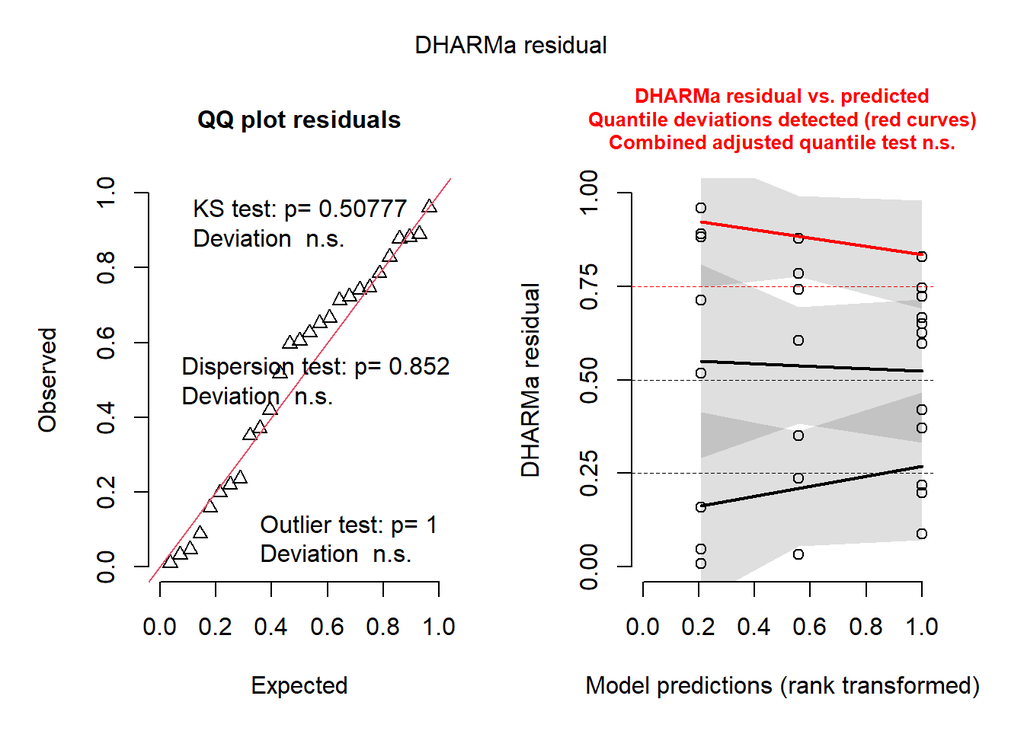

```r
# CTmax
simulationOutput <- simulateResiduals(SWmod1, n = 1000)

plot(simulationOutput) #upper quantile dev detected but adjusted is ns
```

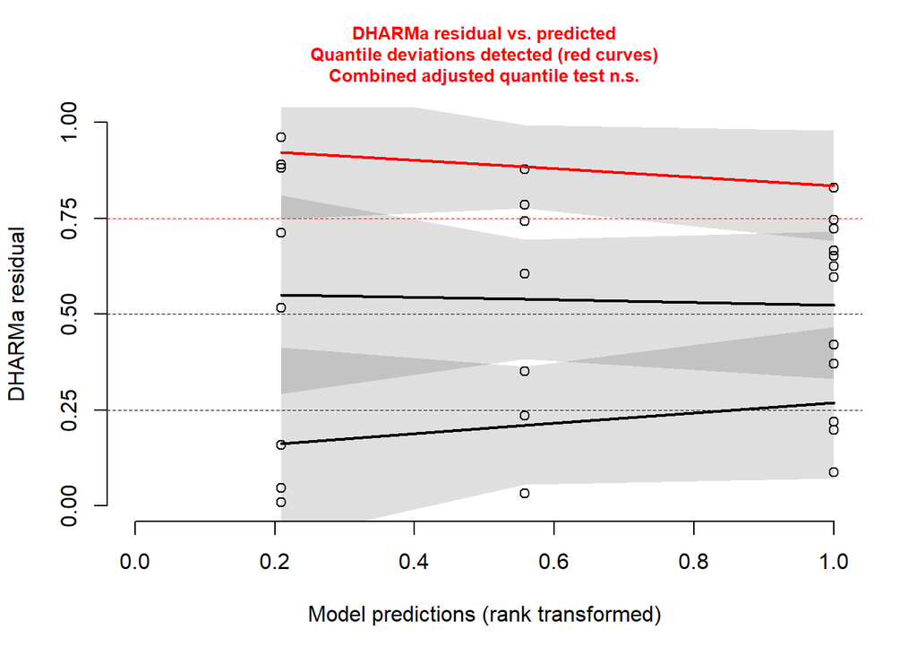

```r
plotResiduals(simulationOutput) #upper quantile dev detected but adjusted is ns
```

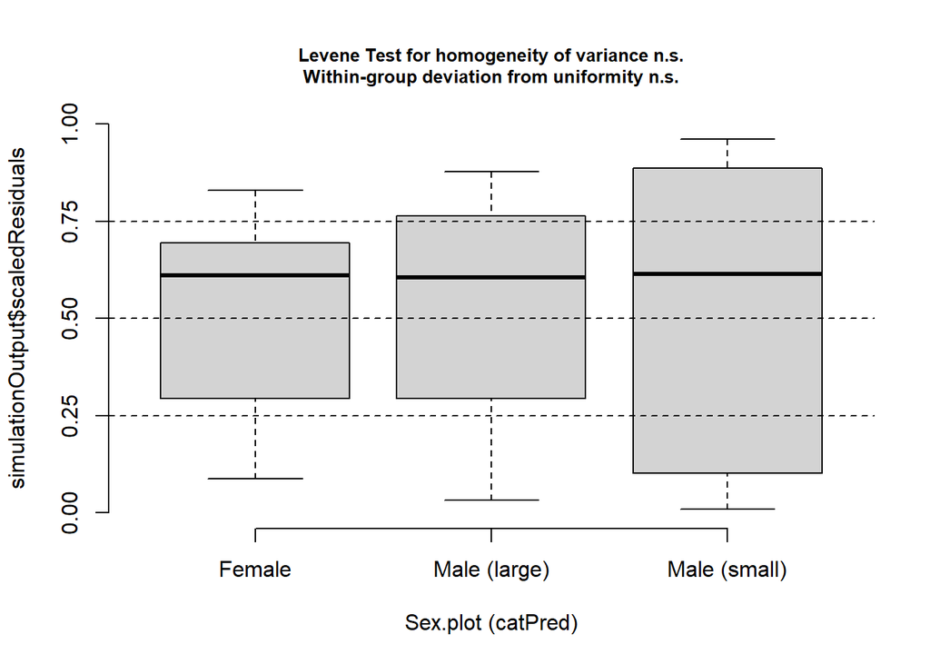

```r
plotResiduals(simulationOutput, form = O.swordtail.df$Sex.plot)
```

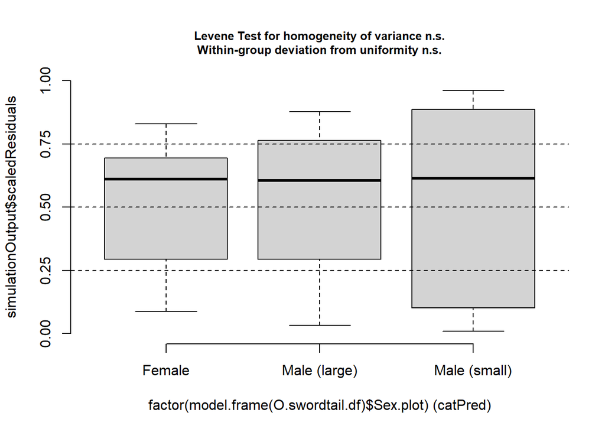

```r
cat_test <- testCategorical(simulationOutput, catPred = factor(model.frame(O.swordtail.df)$Sex.plot))
```

```r
cat_test$uniformity$p.value.cor # all = 1
```

```
## [1] 1 1 1
```

```r
cat_test$homogeneity #p = 0.238
```

```
## Levene's Test for Homogeneity of Variance (center = median)
##       Df F value Pr(>F)
## group  2  1.5232 0.2384
##       24
```

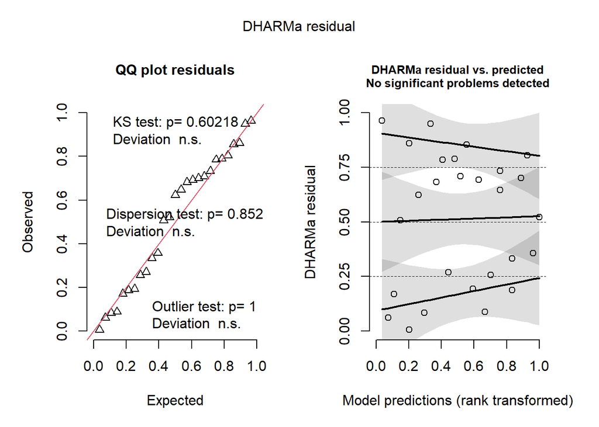

```r
  ### All good!


simulationOutput <- simulateResiduals(SWmod2, n = 1000)

plot(simulationOutput)
```

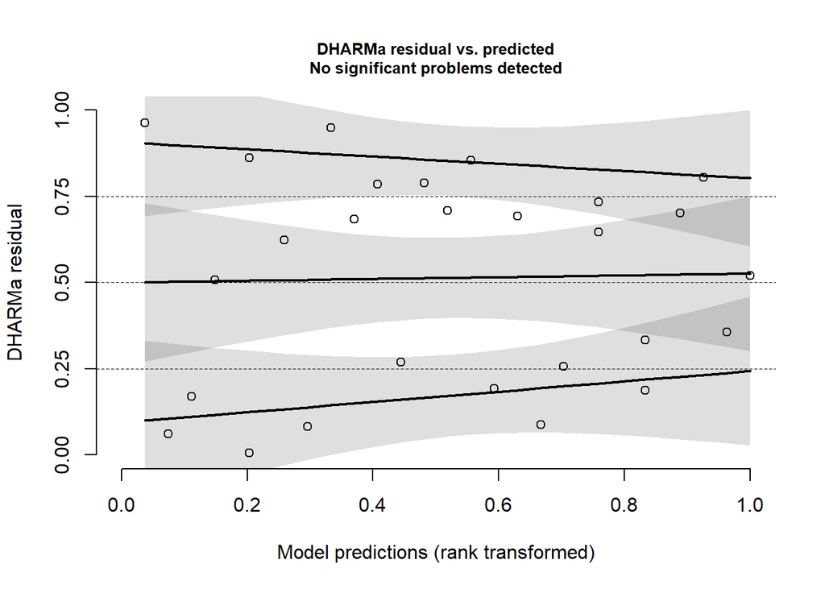

```r
plotResiduals(simulationOutput)
```

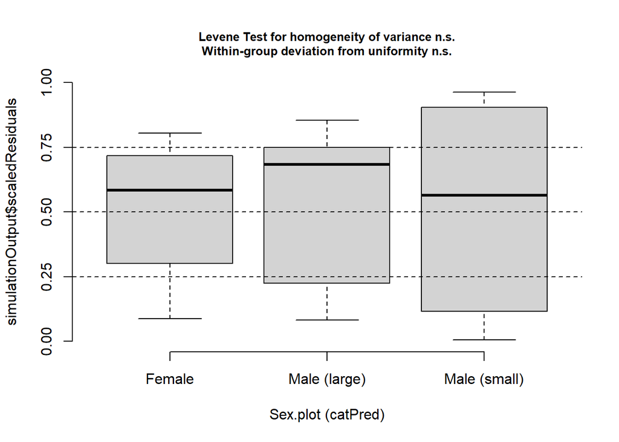

```r
plotResiduals(simulationOutput, form = O.swordtail.df$Sex.plot)
```

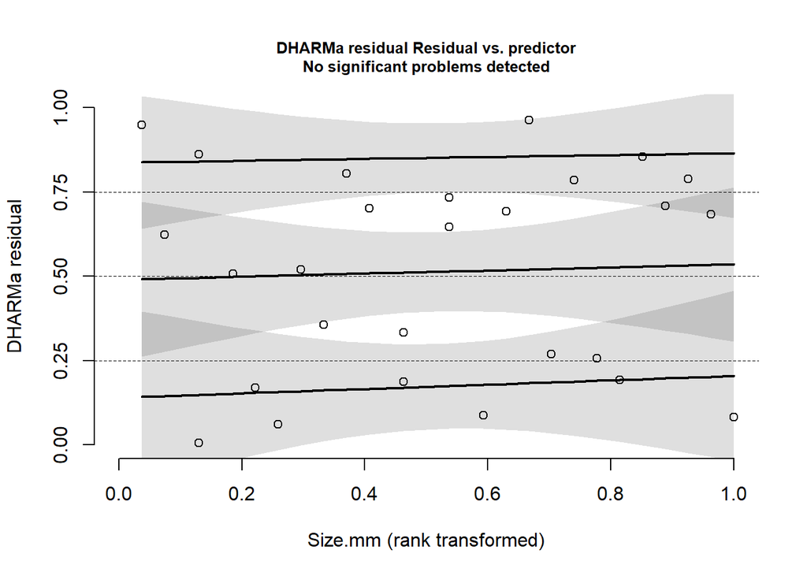

```r
plotResiduals(simulationOutput, form = O.swordtail.df$Size.mm)
```

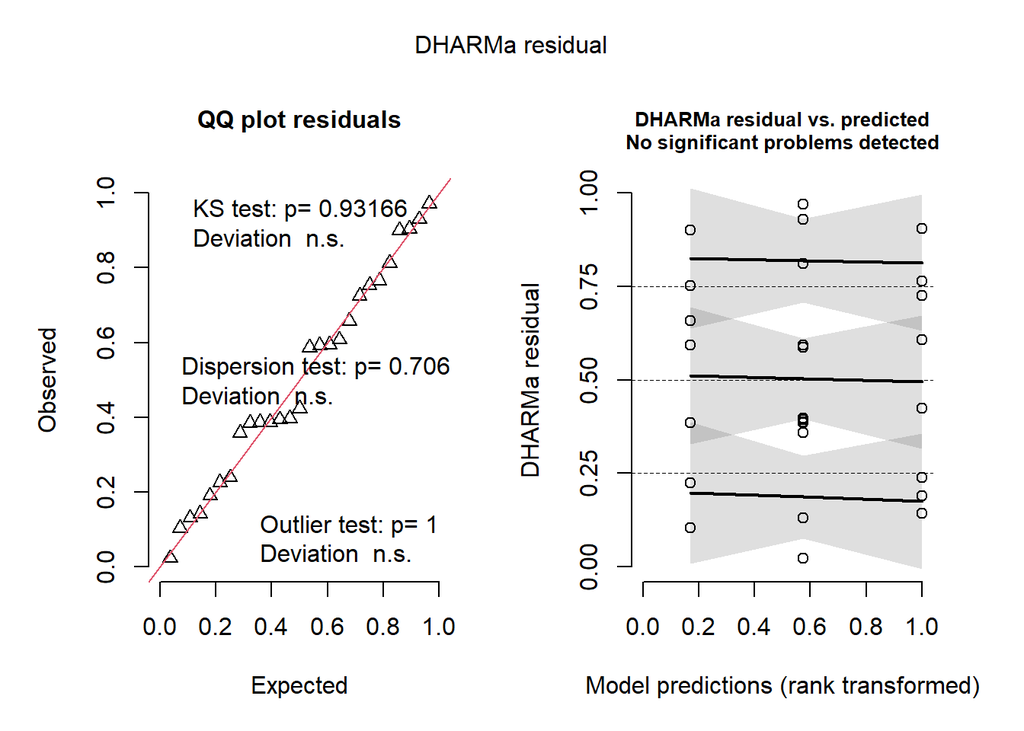

```r
  ### All good!

# CTmin
simulationOutput <- simulateResiduals(SWmod4, n = 1000)

plot(simulationOutput)
```

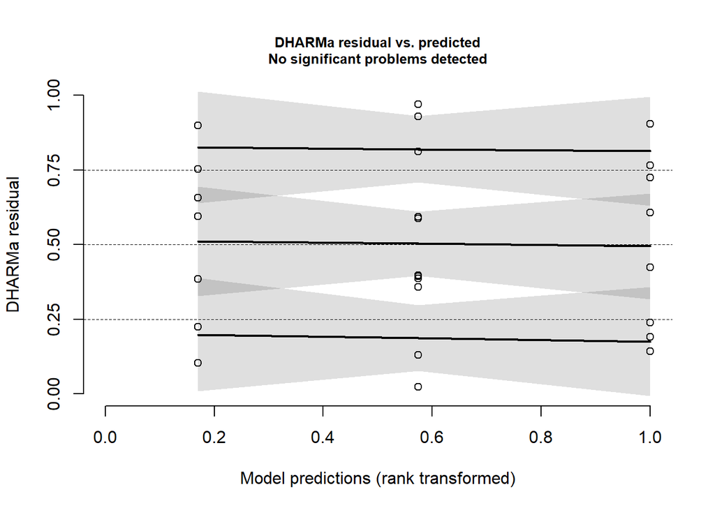

```r
plotResiduals(simulationOutput)
```

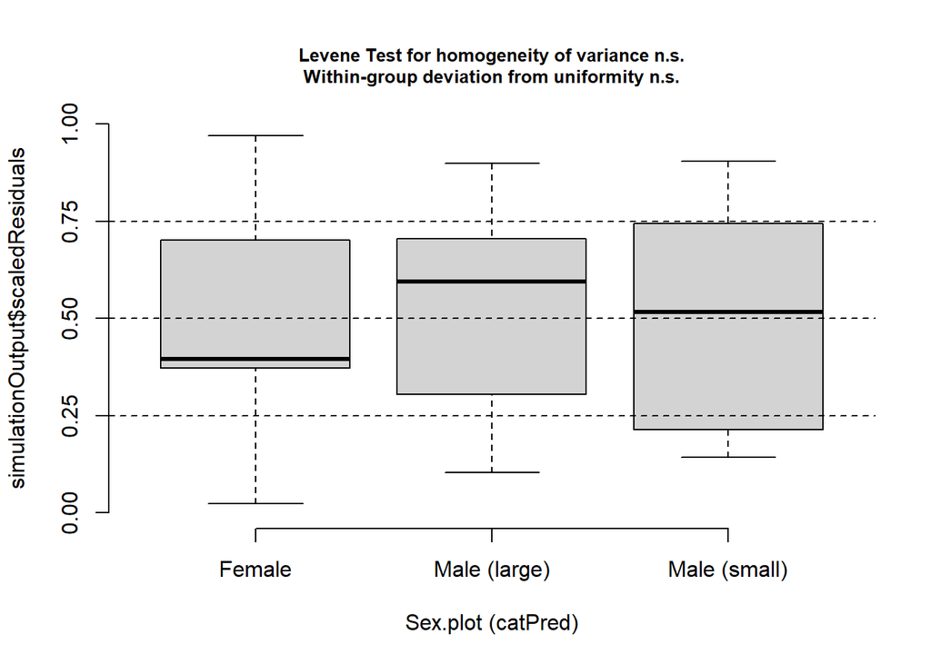

```r
plotResiduals(simulationOutput, form = O.swordtail.df$Sex.plot)
```

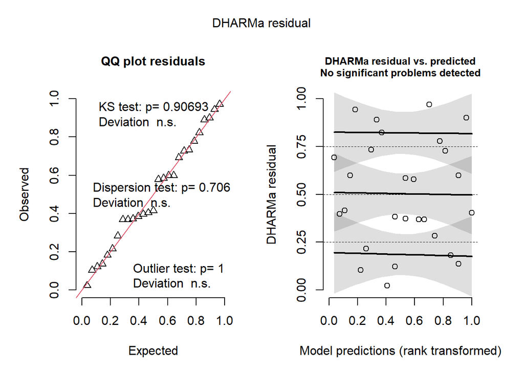

```r
  ### All good!


simulationOutput <- simulateResiduals(SWmod5, n = 1000)

plot(simulationOutput)
```

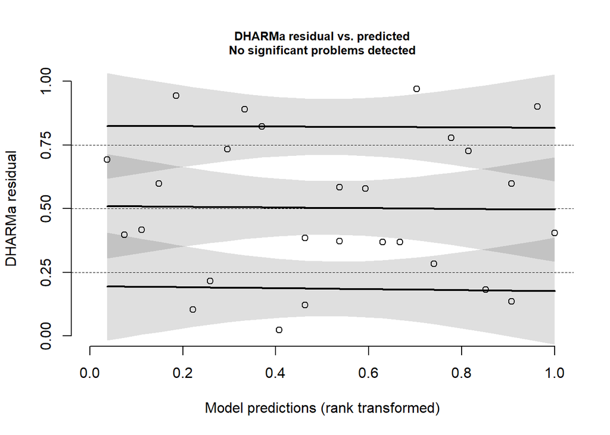

```r
plotResiduals(simulationOutput)
```

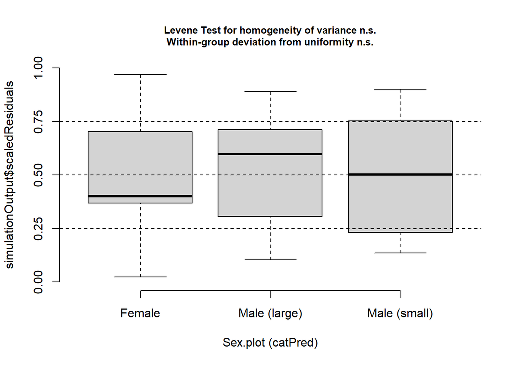

```r
plotResiduals(simulationOutput, form = O.swordtail.df$Sex.plot)
```

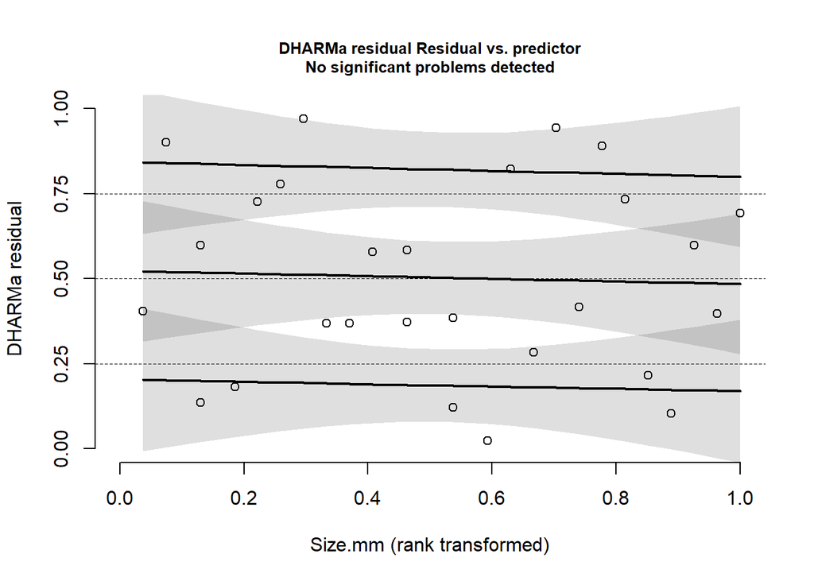

```r
plotResiduals(simulationOutput, form = O.swordtail.df$Size.mm)
```

```r
  ### All good!
```

### Model Summary

**Results:** Sex category (large male, small male, female) did not significantly affect thermal tolerance within swordtails across both temperature categories (CTmax: p=0.091; CTmin: p=0.123). However, there was a significant difference in females and small males within the sex category + size model, although this difference is marginal (p=0.046).

```r
### CTmax ###

# SEX CATEGORY ONLY MODEL
 ## Overall sex category effect
anova(SWmod1, type = 2, ddf = "Satterthwaite") #not significant (p=0.091)
```

```
## Type II Analysis of Variance Table with Satterthwaite's method
##          Sum Sq Mean Sq NumDF DenDF F value  Pr(>F)
## Sex.plot 1.6547 0.82734     2    27  2.6184 0.09134 .
## ---
## Signif. codes:  0 '***' 0.001 '**' 0.01 '*' 0.05 '.' 0.1 ' ' 1
```

```r
 ## EMM & Pairwise comparisons

PW.sw.max <- emmeans(SWmod1, "Sex.plot", lmer.df = "satterthwaite")
summary(PW.sw.max) #EMM
```

```
##  Sex.plot     emmean    SE df lower.CL upper.CL
##  Female         35.7 0.162 27     35.4     36.1
##  Male (large)   35.6 0.212 27     35.2     36.0
##  Male (small)   35.2 0.199 27     34.8     35.6
##
## Degrees-of-freedom method: satterthwaite
## Confidence level used: 0.95
```

```r
summary(pairs(PW.sw.max), infer = c(TRUE,TRUE), level = 0.95, adjust = "holm") #Pairwise results
```

```
##  contrast                    estimate    SE df lower.CL upper.CL t.ratio
##  Female - Male (large)          0.155 0.267 27  -0.5274    0.837   0.580
##  Female - Male (small)          0.582 0.257 27  -0.0733    1.236   2.267
##  Male (large) - Male (small)    0.427 0.291 27  -0.3160    1.169   1.466
##  p.value
##   0.5669
##   0.0949
##   0.3083
##
## Degrees-of-freedom method: satterthwaite
## Confidence level used: 0.95
## Conf-level adjustment: bonferroni method for 3 estimates
## P value adjustment: holm method for 3 tests
```

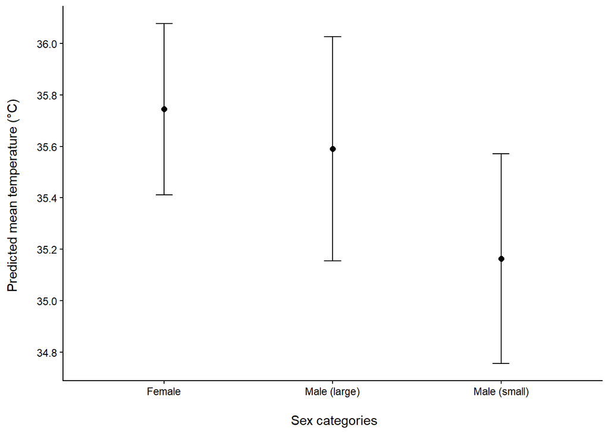

```r
 ## Plotting EMM

PW.df.sw <- as.data.frame(confint(PW.sw.max))

ggplot(PW.df.sw, aes(x=Sex.plot, y=emmean)) +
  geom_point(size=2) +
  geom_errorbar(aes(ymin=lower.CL, ymax=upper.CL), width=0.1) +
  scale_y_continuous(breaks = scales::pretty_breaks(n = 10)) +
  ylab("Predicted mean temperature (°C) \n") +
  xlab("\n Sex categories") +
  theme_classic()
```

```r
# SEX CATEGORY & SIZE MODEL

summary(SWmod2)
```

```
## Linear mixed model fit by maximum likelihood . t-tests use Satterthwaite's
##   method [lmerModLmerTest]
## Formula: CTmax.C ~ Sex.plot + Size.mm + (1 | file.id.max)
##    Data: O.swordtail.df
##
##       AIC       BIC    logLik -2*log(L)  df.resid
##      56.1      63.9     -22.1      44.1        21
##
## Scaled residuals:
##     Min      1Q  Median      3Q     Max
## -2.2668 -0.7587  0.2665  0.7052  1.7822
##
## Random effects:
##  Groups      Name        Variance Std.Dev.
##  file.id.max (Intercept) 0.0000   0.0000
##  Residual                0.3002   0.5479
## Number of obs: 27, groups:  file.id.max, 4
##
## Fixed effects:
##                      Estimate Std. Error       df t value Pr(>|t|)
## (Intercept)          37.23512    1.26278 27.00000  29.487   <2e-16 ***
## Sex.plotMale (large)  0.56655    0.66025 27.00000   0.858   0.3984
## Sex.plotMale (small) -0.78668    0.30379 27.00000  -2.590   0.0153 *
## Size.mm              -0.06486    0.05453 27.00000  -1.189   0.2446
## ---
## Signif. codes:  0 '***' 0.001 '**' 0.01 '*' 0.05 '.' 0.1 ' ' 1
##
## Correlation of Fixed Effects:
##             (Intr) Sx.pltM(l) Sx.pltM(s)
## Sx.pltM(lr)  0.882
## Sx.pltM(sm) -0.628 -0.397
## Size.mm     -0.992 -0.919      0.568
## optimizer (nloptwrap) convergence code: 0 (OK)
## boundary (singular) fit: see help('isSingular')
```

```r
anova(SWmod2, type = 2, ddf = "Satterthwaite") #sex category marginal (p=0.049)
```

```
## Type II Analysis of Variance Table with Satterthwaite's method
##           Sum Sq Mean Sq NumDF DenDF F value  Pr(>F)
## Sex.plot 2.02355 1.01178     2    27  3.3699 0.04937 *
## Size.mm  0.42475 0.42475     1    27  1.4147 0.24464
## ---
## Signif. codes:  0 '***' 0.001 '**' 0.01 '*' 0.05 '.' 0.1 ' ' 1
```

```r
PW.sw.max2 <- emmeans(SWmod2, "Sex.plot", lmer.df = "satterthwaite")
summary(PW.sw.max2) #EMM
```

```
##  Sex.plot     emmean    SE df lower.CL upper.CL
##  Female         35.6 0.191 27     35.2     36.0
##  Male (large)   36.2 0.542 27     35.1     37.3
##  Male (small)   34.8 0.339 27     34.1     35.5
##
## Degrees-of-freedom method: satterthwaite
## Confidence level used: 0.95
```

```r
pairs(PW.sw.max2, adjust = "holm") #Pairwise results: female and sm.male marginal (p=0.046)
```

```
##  contrast                    estimate    SE df t.ratio p.value
##  Female - Male (large)         -0.567 0.660 27  -0.858  0.3984
##  Female - Male (small)          0.787 0.304 27   2.590  0.0459
##  Male (large) - Male (small)    1.353 0.829 27   1.632  0.2285
##
## Degrees-of-freedom method: satterthwaite
## P value adjustment: holm method for 3 tests
```

```r
# CTmin

# SEX CATEGORY ONLY MODEL
 ## Overall sex category effect
anova(SWmod4, type = 2, ddf = "Satterthwaite") #not significant (p=0.123)
```

```
## Type II Analysis of Variance Table with Satterthwaite's method
##           Sum Sq Mean Sq NumDF  DenDF F value Pr(>F)
## Sex.plot 0.71391 0.35696     2 25.016  2.2773 0.1234
```

```r
 ## EMM & Pairwise comparisons

PW.sw.min <- emmeans(SWmod4, "Sex.plot", lmer.df = "satterthwaite")
summary(PW.sw.min) #EMM
```

```
##  Sex.plot     emmean    SE   df lower.CL upper.CL
##  Female         9.78 0.224 5.81     9.23     10.3
##  Male (large)   9.74 0.260 8.96     9.15     10.3
##  Male (small)  10.20 0.256 8.33     9.61     10.8
##
## Degrees-of-freedom method: satterthwaite
## Confidence level used: 0.95
```

```r
summary(pairs(PW.sw.min), infer = c(TRUE,TRUE), level = 0.95, adjust = "holm") #Pairwise results
```

```
##  contrast                    estimate    SE   df lower.CL upper.CL t.ratio
##  Female - Male (large)         0.0479 0.224 26.6   -0.525    0.621   0.214
##  Female - Male (small)        -0.4174 0.199 25.3   -0.928    0.093  -2.097
##  Male (large) - Male (small)  -0.4653 0.287 26.9   -1.197    0.266  -1.623
##  p.value
##   0.8325
##   0.1386
##   0.2324
##
## Degrees-of-freedom method: satterthwaite
## Confidence level used: 0.95
## Conf-level adjustment: bonferroni method for 3 estimates
## P value adjustment: holm method for 3 tests
```

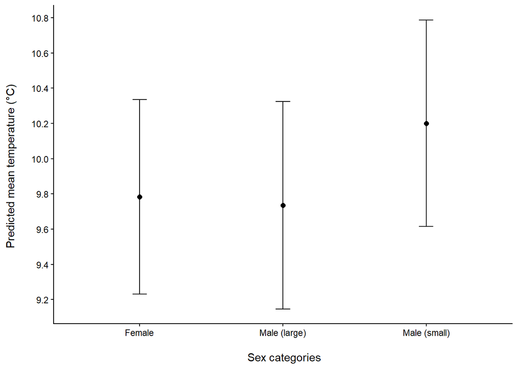

```r
 ## Plotting EMM

PW.df.sw2 <- as.data.frame(confint(PW.sw.min))

ggplot(PW.df.sw2, aes(x=Sex.plot, y=emmean)) +
  geom_point(size=2) +
  geom_errorbar(aes(ymin=lower.CL, ymax=upper.CL), width=0.1) +
  scale_y_continuous(breaks = scales::pretty_breaks(n = 10)) +
  ylab("Predicted mean temperature (°C) \n") +
  xlab("\n Sex categories") +
  theme_classic()
```

### Sensitivity analysis

As our design has single-male morph runs (i.e. only large males or only small males), we test the sensitivity of our results to the variance estimated for clustered experimental trials. CR2 (cluster-robust standard errors) with Satterthwaite small-sample correction will be used.

**RESULTS:** Overall sex category effect is still not significant for CTmax, although a significant female-small male difference does appear for CTmax model that includes size. The female-small male difference is also significant in CTmin but only for the sex category model; including size makes this comparison non-significant. However, there are very few trials per morph type, and the sex/moprh classes do not overlap in size, so comparisons are then made on extrapolated data.

```r
#robust coeff for mods1,2,4,5
conf_int(SWmod1, vcov = "CR2", level = 0.95, test = "Satterthwaite", p_values = TRUE) #sex category still not sig
```

```
##                 Coef. Estimate     SE d.f. Lower 95% CI Upper 95% CI p-value
##           (Intercept)   35.745 0.0959 2.44        35.40       36.093  <0.001
##  Sex.plotMale (large)   -0.155 0.3702 1.74        -2.00        1.694   0.721
##  Sex.plotMale (small)   -0.582 0.2669 1.61        -2.05        0.882   0.191
##  Sig.
##   ***
##
##
```

```r
conf_int(SWmod2, vcov = "CR2", level = 0.95, test = "Satterthwaite", p_values = TRUE) #sex category for small male sig (p=0.034) but not sig for large male or size
```

```
##                 Coef. Estimate    SE d.f. Lower 95% CI Upper 95% CI p-value
##           (Intercept)  37.2351 1.290 2.07       31.870       42.600  <0.001
##  Sex.plotMale (large)   0.5666 0.664 2.42       -1.861        2.994  0.4695
##  Sex.plotMale (small)  -0.7867 0.112 1.61       -1.404       -0.169  0.0343
##               Size.mm  -0.0649 0.059 2.03       -0.315        0.185  0.3848
##  Sig.
##   ***
##
##     *
##
```

```r
conf_int(SWmod4, vcov = "CR2", level = 0.95, test = "Satterthwaite", p_values = TRUE) #sex category is sig for small male (p=0.043) but not large male
```

```
##                 Coef. Estimate     SE d.f. Lower 95% CI Upper 95% CI p-value
##           (Intercept)   9.7838 0.2866 2.90       8.8541       10.713  <0.001
##  Sex.plotMale (large)  -0.0479 0.5206 1.14      -5.0022        4.906  0.9401
##  Sex.plotMale (small)   0.4174 0.0344 1.09       0.0554        0.779  0.0429
##  Sig.
##   ***
##
##     *
```

```r
conf_int(SWmod5, vcov = "CR2", level = 0.95, test = "Satterthwaite", p_values = TRUE) #sex category is marginal for small male (p=0.054) but large male and size still not sig
```

```
##                 Coef. Estimate     SE d.f. Lower 95% CI Upper 95% CI p-value
##           (Intercept)  10.0744 0.4268 1.97       8.2070      11.9419 0.00195
##  Sex.plotMale (large)   0.0979 0.4515 2.10      -1.7586       1.9544 0.84759
##  Sex.plotMale (small)   0.3778 0.0527 1.29      -0.0221       0.7778 0.05375
##               Size.mm  -0.0128 0.0112 1.84      -0.0652       0.0397 0.38084
##  Sig.
##    **
##
##     .
##
```

```r
#overall species effects

robVCV.sw.max <- vcovCR(SWmod1, type = "CR2")

Wald_test(SWmod1, constraints = constrain_zero(grep("^Sex.plot", names(fixef(SWmod1)))), vcov = robVCV.sw.max, test = "HTZ")
```

```
##  test Fstat df_num df_denom p_val sig
##   HTZ  1.27      2    0.971 0.536
```

```r
robVCV.sw.min <- vcovCR(SWmod4, type = "CR2")

Wald_test(SWmod4, constraints = constrain_zero(grep("^Sex.plot", names(fixef(SWmod4)))), vcov = robVCV.sw.min, test = "HTZ")
```

```
##  test Fstat df_num df_denom p_val sig
##   HTZ  62.1      2    0.611 0.197
```